# Performances des industries agroalimentaires

Industries agroalimentaires

Premier producteur agricole de l’Union européenne, la France dispose aussi d’une puissante force de transformation avec ses industries agroalimentaires (IAA). En chiffre d’affaires ou en valeur ajoutée, seule l’Allemagne la dépasse, depuis 2015.

Retour à l’accueil

Partager la dataviz

Explorer les données territoriales

Partager

Accueil

# **Performances économiques des industires agroalimentaires**

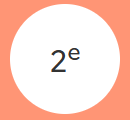

C’est le rang des industries agroalimentaires françaises au sein de l’union européenne.

Classée juste derrière l’Allemagne ces dernières années, la France devance nettement l’Italie et l’Espagne.

## **Valeur ajoutée des industries agroalimentaires dans l’Union européenne**

Prix courants, en milliards d’euros

[figure not shown]

Champ : branche des industries agroalimentaires  
Source : Eurostat

Les industries agroalimentaires (IAA) sont le premier secteur manufacturier ? L'industrie manufacturière regroupe les industries de transformation des biens, mais aussi la réparation et l'installation d'équipements industriels. français, en chiffre d'affaires, en valeur ajoutée ou en emploi salarié. ? Rapportées à l’ensemble de l’industrie manufacturière, les IAA comptent pour 16 % des effectifs (ETP), 20 % du chiffre d’affaires et 16 % de la valeur ajoutée en 2021. Elles génèrent par exemple 2,3 fois plus de valeur ajoutée que l’industrie automobile.

Depuis des décennies, les IAA assurent un volume d’emploi salarié remarquablement stable, en croissance même depuis 2015. Cette évolution est plus favorable que celle de l’ensemble de l’industrie manufacturière.

## **Evolution de l’emploi salarié hors intérim des branches agroalimentaire et manufacturière**

Indice en base 100 en 1990

[figure not shown]

*y compris l’artisanat commercial  
Champ : France hors Mayotte  
Source : Insee, comptes nationaux, base 2024

# **Les IAA sont un acteur clé d’un vaste ensemble agricole et agroalimentaire**

Les IAA forment un maillon essentiel d’une chaîne de valorisation qui va des fermes agricoles jusqu’aux consommateurs (à domicile ou au restaurant), en passant par les commerçants de gros et de détail. IAA et agriculture dégagent en 2022 une valeur ajoutée similaire. Ensemble, elles contribuent pour près de 4 % au produit intérieur brut (PIB) national (à hauteur de 100 milliards d’euros).

## **Part de la valeur ajoutée de l’agriculture et des IAA dans le PIB**

En %

[figure not shown]

*Agriculture, sylviculture et pêche  
Champ : France  
Source : Insee, comptes nationaux, base 2024

L'analyse sectorielle ? L’approche « sectorielle » privilégie l’activité principale, écartant par exemple les entreprises qui font principalement de la distribution. En comptabilité nationale en revanche, la « branche » IAA couvre uniquement les activités d’IAA, mais dans l’ensemble des entreprises. qui suit distingue l’industrie de l’artisanat commercial. ? L’artisanat commercial regroupe les unités ayant pour activité principale la charcuterie, la boulangerie, la boulangerie-pâtisserie, la pâtisserie, la cuisson de produits de boulangerie. Il concerne pour l’essentiel des entreprises de moins de 10 salariés, par ailleurs inscrites au Répertoire des métiers. Elle écarte aussi les activités de transformation « à la ferme » ? En particulier, certains domaines viticoles vinifient, embouteillent et commercialisent eux-mêmes ; ils ne figurent pas, statistiquement, dans les IAA. , en vente directe, et le commerce de gros.

En 2021, 19 000 entreprises ? Les statisticiens définissent désormais l’entreprise comme la plus petite combinaison d’unités légales formant une unité organisationnelle, avec une certaine autonomie de décision. Il peut s’agir d’entreprises indépendantes ou de groupes comprenant plusieurs filiales. entrent ainsi dans le champ des industries agroalimentaires stricto sensu. De leur côté, les entreprises du commerce de gros ou de l’artisanat commercial alimentaire sont plus nombreuses. Mais elles emploient moins de salariés. Les IAA génèrent deux fois plus de valeur ajoutée qu'artisanat et commerce de gros alimentaires réunis.

## **Indicateurs du secteur agroalimentaire en France en 2021**

[figure not shown]

Md€ : milliards d’euros  
ETP : équivalent temps plein  
Source : Insee - Esane, traitements SSP

Pour mieux comprendre une notion comptable comme la valeur ajoutée, supposons qu’une entreprise fabrique des biscuits. La production vendue – le chiffre d’affaires – doit d’abord servir à payer les matières premières et l’énergie, qui font partie des « consommations intermédiaires ». Ce qu’il reste est par définition la valeur ajoutée, soit la richesse créée lors du processus de production.

[figure not shown]

L’entreprise utilisera cette valeur ajoutée pour payer les salariés, les impôts sur les bénéfices, les frais financiers, amortir son matériel, rémunérer les actionnaires et investir.

# **Comment se déclinent les IAA selon les activités ?**

Les industries agroalimentaires recouvrent une dizaine d'activités ? D'une grande diversité, comme par exemple des abattoirs, des caves coopératives viticoles, des petits fabricants de fromage, des usines de production d'huiles, de fabrication d'eaux minérales ou de produits transformés à base de fruits (compotes, jus de fruits)... , de transformation végétale ou animale et de fabrication de boissons.

Quatre activités génèrent les trois quarts de la valeur ajoutée des IAA. Au premier rang : la fabrication de boissons (vin, bière, spiritueux, boissons non alcoolisées hors jus de fruits) avec 22% de l’ensemble.

## **Valeur ajoutée dans les IAA en 2021**

En milliards d’euros

[figure not shown]

*plats préparés, sucre, confiserie, cacao, thé, café, condiments…  
**produits de l’extraction de l’amidon des végétaux utilisés dans l’alimentation (amidon, glucoses, gluten, tapioca…)  
Champ : IAA hors artisanat commercial et tabac - France  
Source : Insee - Esane, traitements SSP

L’activité des boissons domine la valeur ajoutée car elle représente le plus fort taux de valeur ajoutée. C’est celle où les matières premières pèsent le moins dans le processus de production.

Les activités de transformation de viande emploient le plus de salariés : elles ont besoin de davantage de main-d’oeuvre pour produire.

En matière de chiffre d’affaire, les produits laitiers arrivent en tête, mais leur valeur ajoutée est inférieure à celle des boissons ou des autres produits alimentaires.

## **Palmarès des activités des IAA en 2021**

[figure not shown]

Champ : IAA hors artisanat commercial et tabac - France  
Source : Insee - Esane, traitements SSP

Comparons les boissons avec l’activité qui lui est la plus opposée pour le taux de valeur ajoutée, celle des huiles et graisses.

Dans la fabrication des boissons, les matières premières sont relativement peu coûteuses, en regard de la valorisation du produit final.

[figure not shown]

Pour produire des huiles et des graisses, ? Fabrication d'huiles et de graisses brutes et raffinées d'origine végétale ou animale (excepté les graisses animales comestibles comme par exemple le saindoux, le suif, ou le beurre). les matières premières pèsent davantage. Plus souvent importées, elles sont aussi davantage sujettes à des variations de prix.

[figure not shown]

Le calssement suivant traduit le degré de transformation des différentes filières des IAA.

En bas de figure, juste avant les huiles et graisses, la production de farine et d’amylacés (amidon) illustre la notion de première transformation, dont les débouchés peuvent alimenter les filières de seconde transformation, à plus forte valeur ajoutée.

## **Taux de valeur ajoutée dans les IAA en 2021**

[figure not shown]

Champ : IAA hors artisanat commercial et tabac - France  
Source : Insee - Esane, traitements SSP

Le taux de valeur ajoutée n’est pas à lui seul un indicateur d’efficacité ou de rentabilité économique

Pour apprécier la rentabilité, il faut retirer de la valeur ajoutée les frais de personnel.

Apparait ainsi, l’éxcédent brut d’exploitation (EBE) - appelé plus communément la “marge”.

Apparait ainsi, l'éxcédent brut d'exploitation (EBE) - appelé plus communément la "marge" ? La marge sert à payer les impôts, amortir le matériel, couvrir les frais financiers, rémunérer les actionnaires et investir. .

[figure not shown]

Le “taux de marge” rapporte cette marge à la valeur ajoutée. Moins les frais de personnel pèsent dans la valeur ajoutée, plus ce taux est élevé.

Les activités de fabrication de boissons affichent un taux de marge supérieur à 50 %, cas assez rare dans l’industrie manufacturière.

A l’opposé, les activités de transformation de viande mobilisnet beaucoup de main-d’oeuvre, elles dégagent moins de marge en moyenne.

## **Taux de marge dans les IAA**

Moyenne 2020-2021

[figure not shown]

Champ : IAA hors artisanat commercial et tabac - France  
Source : Insee - Esane, traitements SSP

Comparées à la moyenne de l’industrie manufacturière, les IAA affichent un taux de valeur ajoutée plus faible (20 % contre 26 %) mais un meilleur taux de marge (33 % contre 25 %), et un taux d’investissement ? Le taux d’investissement mesure la part des investissements dans la valeur ajoutée. plus élevé (19 % contre 15 %).

Marlgré des marges importantes, les secteurs des boissons et des aliments pour animaux sont ceux qui investissent le moins (en proportion de la valeur ajoutée), dans la période 2020-2021.

A l’inverse, les huiles et graissent présentent un taux senssiblement supérieur aux autres activités.

## **Taux d’investissement dans les IAA**

Moyenne 2020-2021

[figure not shown]

Champ : IAA hors artisanat commercial et tabac - France  
Source : Insee - Esane, traitements SSP

# **Quels résultats en fonction de la taille des entreprises ?**

Les industries agroalimentaires reposent pour l’essentiel sur des microentreprises (83 % en 2021). Cependant, les 350 entreprises dites « grandes » ou de taille intermédiaire (ETI) ? La loi de modernisation de l’économie de 2008 définit de nouvelles catégories d’entreprises, à partir de critères multiples et plus du seul effectif salarié. Outre des seuils d’effectifs (10, 50, 250, 5 000 salariés), elle considère l’activité. Par exemple une entreprise de moins de 250 salariés mais dont le CA dépasse 50 M€ et le total de bilan 43 M€ sera classée ETI et non PME. réalisent 85 % du chiffre d’affaires et des exportations et 83 % de la valeur ajoutée ? Les 24 plus grandes entreprises génèrent à elles seules 40 % de la valeur ajoutée des IAA. du secteur.

## **Indicateurs synthétiques par catégorie d’entreprise en 2021**

[figure not shown]

# **Comment se portent les échanges extérieurs des IAA ?**

Le taux d’exportation ? Le taux d’exportation mesure la part des exportations dans le chiffre d’affaires total. moyen des industries agroalimentaires s’établit à 25 % en 2021, un taux sensiblement inférieur à la moyenne de l’industrie manufacturière (42 %) : les IAA servent en priorité le marché national.

De gros écarts se dessinent selon les activités.

Les industries de produits périssables (viandes, poissons, boulangerie industrielle) exportent moins que les autres.

A l’inverse, les industries des huiles et graisses ou des farines et amylacés exportent près de la moitié de leur production.

# **Taux d’exportation des IAA en 2021**

[figure not shown]

Champ : IAA hors artisanat commercial et tabac - France  
Source : Insee - Esane, traitements SSP

La France est le 6e exportateur mondial de produits agricoles bruts et transformés, derrière les États-Unis, les Pays-Bas, l’Allemagne, le Brésil et la Chine. Les IAA françaises sont, depuis longtemps, exportatrices nettes ? Elles exportent plus qu’elles n’importent. de produits transformés, caractéristiques qu’elles partagent avec leurs homologues espagnoles, italiennes ou néerlandaises. En revanche, si l’Allemagne exporte davantage que la France, elle importe plus qu’elle n’exporte et présente donc une balance commerciale ? La balance commerciale représente la différence entre la valeur des exportations et des importations de biens. structurellement déficitaire.

## **Solde des échanges agroalimentaires français pour différents produits en 2022**

En milliards d’euros

[figure not shown]

Source : Douanes

Depuis 10 ans au moins, la balance commerciale française est assez stable, entre 5 et 8 millairs d’euros chaque année. Mais aliments et boissons connaissent des évolutions nettement divergentes.

Parenthèse Covid mise à part, la fabrication de boissons accroit régulièrement ses performances à l’export - grâce aux prix, alors que les volumes baissent sur les années récentes.

En revanche, la balance commerciale française est de plus en plus déficitaire dans les produits alimentaires, et tout particulièrement pour la transformation de viande.

[figure not shown]

*les statistiques des douanes incorporent le tabac, mais cette activité est marginale par rapport à celle des boissons.  
Champ : France, y compris Mayotte à partir de 2014.  
Source : Douanes

[figure not shown]

*les statistiques des douanes incorporent le tabac, mais cette activité est marginale par rapport à celle des boissons.  
Champ : France, y compris Mayotte à partir de 2014.  
Source : Douanes

[figure not shown]

*les statistiques des douanes incorporent le tabac, mais cette activité est marginale par rapport à celle des boissons.  
Champ : France, y compris Mayotte à partir de 2014.  
Source : Douanes

# **Comment les IAA se déploient-elles dans le territoire national ?**

En emplois salariés, les IAA apparaissent très présentes dans un quart nord-ouest, en premier lieu en Bretagne et dans les Pays de la Loire. L’Île-de-France accueille par ailleurs nombre de sièges sociaux.

La fabrication de produits laitiers se retrouve dans ce que l’on appelle le « croissant laitier » : un arc qui s’ancre dans un Grand Ouest comprenant la Bretagne, les Pays de la Loire et la Normandie, remonte vers le nord et redescend par les plaines de l’Est, la Franche-Comté et les Alpes du Nord, jusqu’au Massif central (cf. la viz sur les exploitations bovines laitières).

Les industries de transformation se sont développées dans les régions de production laitière, et soutiennent en retour l’activité agricole locale.

Dans la même logique, les industries de transformation de viande se situent très majoritairement en Bretagne et dans les Pays de la Loire.

Enfin, l’implantation des entreprises de fabrication de boissons se reconnait dans les grands bassins viticoles, mais aussi dans quelques zones de gisement d’eau minérale (Vosges, Alpes ou Auvergne).

## Ensemble des IAA : effectifs salariés au 31/12/2021

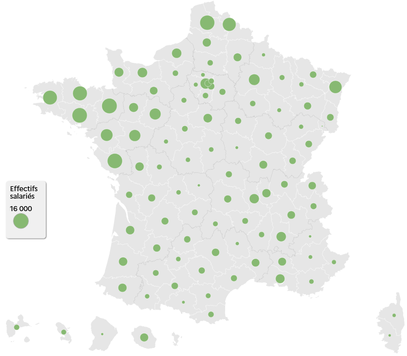

Source : Insee - Flores

## Fabrication de produits laitiers : effectifs salariés au 31/12/2021

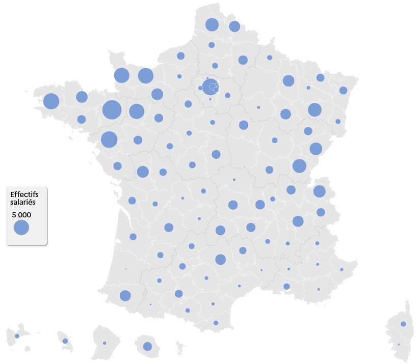

Source : Insee - Flores

## Transformation de viande : effectifs salariés au 31/12/2021

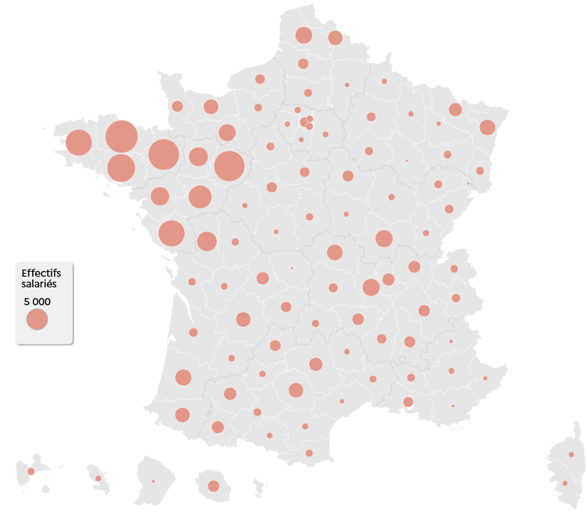

Source : Insee - Flores

## Fabrication de boissons : effectifs salariés au 31/12/2021

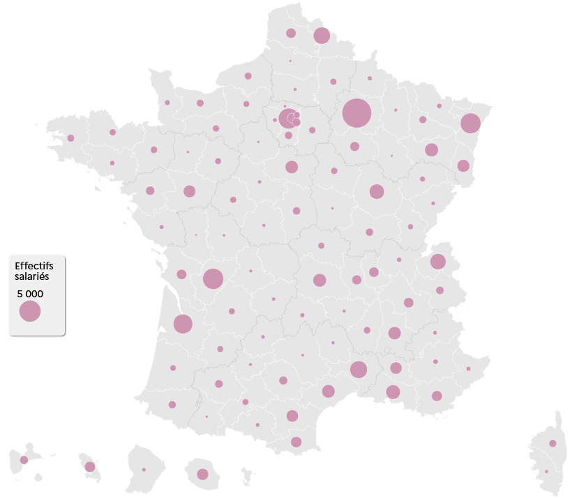

Source : Insee - Flores

**Pour en savoir plus :**

[Résultats économiques des IAA 2021](https://agreste.agriculture.gouv.fr/agreste-web/disaron/Chd2402/detail/)

[Transformation de l’agriculture 2024](https://www.insee.fr/fr/statistiques/7728903)

Panorama des IAA 2022

[Retour à l’accueil de VizAgreste](https://vizagreste.agriculture.gouv.fr/)